# How Gaming Affects Mental Well-Being

Fredy Guevara, Benjamin Lutumba, Sandy Datta

2026-04-24

## 1 1. Introduction

Gaming has become a central part of modern entertainment, with millions of individuals engaging in video games daily. While gaming is often associated with relaxation, competition, and social interaction, there is ongoing debate about its impact on mental well-being.

The purpose of this project is to investigate the following question:

How does gaming affect well-being?

To answer this, we focus on three main psychological outcomes:

Anxiety (GAD_T) Social Anxiety (SPIN_T) Life Satisfaction (SWL_T)

We explore how these outcomes relate to:

Gaming intensity (hours played) Gaming motivation (why people play) Gaming playstyle (who people play with) Demographic factors such as age and residence

By combining data cleaning, grouping techniques, and visualization, this analysis aims to uncover meaningful patterns in how gaming behavior relates to mental health.

Gaming is often viewed as either harmful or beneficial to mental health, but these assumptions are rarely supported by detailed behavioral data. Many people believe that more gaming leads to higher anxiety or lower well-being, but this relationship is not straightforward. This project aims to move beyond that assumption by examining not only how much people play, but also why they play and who they play with. By doing this, we can better understand whether gaming itself affects well-being, or whether other underlying factors drive these patterns. Based on common assumptions, we expect that higher levels of gaming may be associated with increased anxiety and social anxiety, and potentially lower life satisfaction. However, we also expect that factors such as gaming motivation and playstyle may play a significant role in shaping these outcomes.

## 2 2. Packages Required

```r
knitr::opts_chunk$set(echo = FALSE, message = FALSE, warning = FALSE)
#install.packages(c("tidyverse", "readxl", "ggplot2", "ggridges"))
library(readr)
library(dplyr)
library(tidyverse)
library(readxl)
library(ggridges)

# Code Setup
gamingA_raw <- read.csv("GamingStudy_data.csv", stringsAsFactors = FALSE)
names(gamingA_raw)
```

```
##  [1] "X"               "Zeitstempel"     "GAD1"            "GAD2"
##  [5] "GAD3"            "GAD4"            "GAD5"            "GAD6"
##  [9] "GAD7"            "GADE"            "SWL1"            "SWL2"
## [13] "SWL3"            "SWL4"            "SWL5"            "Game"
## [17] "Platform"        "Hours"           "earnings"        "whyplay"
## [21] "League"          "highestleague"   "streams"         "SPIN1"
## [25] "SPIN2"           "SPIN3"           "SPIN4"           "SPIN5"
## [29] "SPIN6"           "SPIN7"           "SPIN8"           "SPIN9"
## [33] "SPIN10"          "SPIN11"          "SPIN12"          "SPIN13"
## [37] "SPIN14"          "SPIN15"          "SPIN16"          "SPIN17"
## [41] "Narcissism"      "Gender"          "Age"             "Work"
## [45] "Degree"          "Birthplace"      "Residence"       "Reference"
## [49] "Playstyle"       "accept"          "GAD_T"           "SWL_T"
## [53] "SPIN_T"          "Residence_ISO3"  "Birthplace_ISO3"
```

```r
str(gamingA_raw)
```

```
## 'data.frame':    13464 obs. of  55 variables:
##  $ X              : int  1 2 3 4 5 6 7 8 9 10 ...
##  $ Zeitstempel    : num  42052 42052 42052 42052 42052 ...
##  $ GAD1           : int  0 1 0 0 2 0 0 0 2 2 ...
##  $ GAD2           : int  0 2 2 0 1 0 0 0 3 1 ...
##  $ GAD3           : int  0 2 2 0 2 0 0 0 2 2 ...
##  $ GAD4           : int  0 2 0 0 2 0 0 0 2 2 ...
##  $ GAD5           : int  1 0 0 0 2 0 0 0 0 2 ...
##  $ GAD6           : int  0 1 3 0 3 1 0 0 1 1 ...
##  $ GAD7           : int  0 0 1 0 2 0 0 0 2 0 ...
##  $ GADE           : chr  "Not difficult at all" "Somewhat difficult" "Not difficult at all" "Not difficult at all" ...
##  $ SWL1           : int  3 3 2 2 2 3 3 3 2 3 ...
##  $ SWL2           : int  5 5 6 5 2 5 4 6 3 3 ...
##  $ SWL3           : int  5 2 5 5 4 3 4 4 3 3 ...
##  $ SWL4           : int  5 5 2 3 5 3 3 3 3 2 ...
```

[output cut: 41 more lines]

```r
# Keep variables we want
gamingA <- gamingA_raw %>%
  select(
    Hours, streams, Game, Platform, whyplay, Playstyle,
    GAD_T, SWL_T, SPIN_T,
    Narcissism, Residence, Age, Work, Degree, Gender
  ) %>%
  drop_na(Hours, GAD_T, SWL_T, SPIN_T)

# Make sure numeric columns are numeric
gamingA <- gamingA %>%
  mutate(
    Hours = as.numeric(Hours),
    streams = as.numeric(streams),
    GAD_T = as.numeric(GAD_T),
    SWL_T = as.numeric(SWL_T),
    SPIN_T = as.numeric(SPIN_T),
    Narcissism = as.numeric(Narcissism),
    Age = as.numeric(Age)
  )

# Remove impossible or extreme values if needed
gamingA <- gamingA %>%
  filter(
    Age >= 18,
    Age < 66,
    Hours >= 0,
    Hours <= 112
  )

# Create a total gaming variable
gamingA <- gamingA %>%
  mutate(total_gaming = Hours + ifelse(is.na(streams), 0, streams))

# Create gaming groups
gamingA <- gamingA %>%
  mutate(
    gaming_level = case_when(
      total_gaming < 5 ~ "Low",
      total_gaming < 15 ~ "Moderate",
      total_gaming < 30 ~ "High",
      TRUE ~ "Extreme"
    ),
    gaming_level = factor(gaming_level,
                          levels = c("Low", "Moderate", "High", "Extreme"))
  )
```

The packages used in this project support data cleaning, transformation, and visualization. The dataset is imported and processed to ensure all variables are in the correct format and that extreme or unrealistic values are removed.

## 3 3. Data Preparation

The dataset used in this project comes from a gaming and mental health survey. It includes information about gaming habits, psychological measures, and demographic variables.

Key preparation steps include:

Selecting only relevant variables Converting values to numeric format Filtering unrealistic values Creating a total gaming variable Grouping individuals into gaming intensity categories

This ensures the data is clean, consistent, and ready for analysis. The data was cleaned to ensure meaningful analysis. Unrealistic values, such as extremely high gaming hours or invalid ages, were removed to prevent distortion. A total gaming variable was created to capture both playing and streaming activity, providing a more complete measure of engagement. Gaming levels were then grouped into categories (Low, Moderate, High, Extreme) to simplify comparisons and allow clearer interpretation of patterns across different intensities. These preprocessing steps ensure that the analysis is based on consistent and reliable data, allowing for more meaningful comparisons across different groups.

## 4 4. Exploratory Data Analysis

Gaming Habits Overview

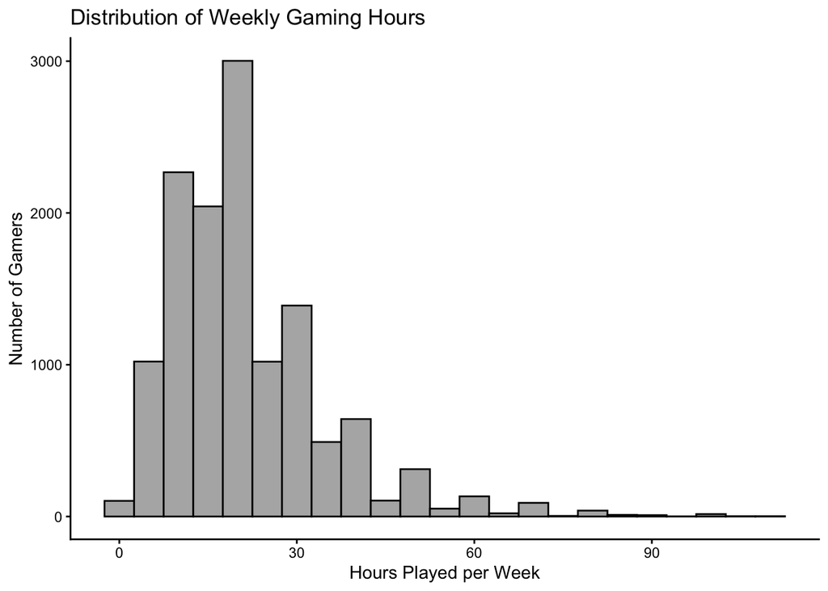

Psychological Effects of Gaming Anxiety vs Gaming Level

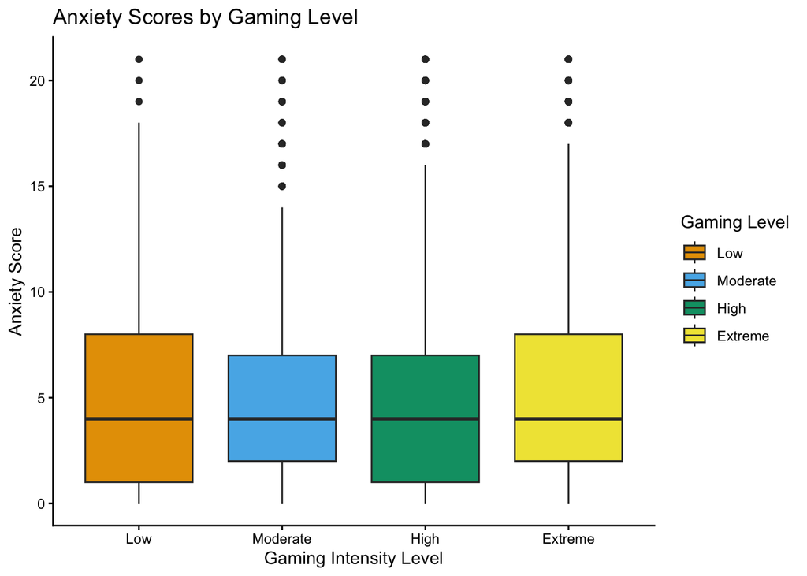

The large overlap between groups suggests that gaming intensity alone is not a strong predictor of anxiety. This indicates that other variables, such as personal characteristics or external life factors, may have a greater influence on anxiety than gaming behavior itself.

Average Anxiety Trends

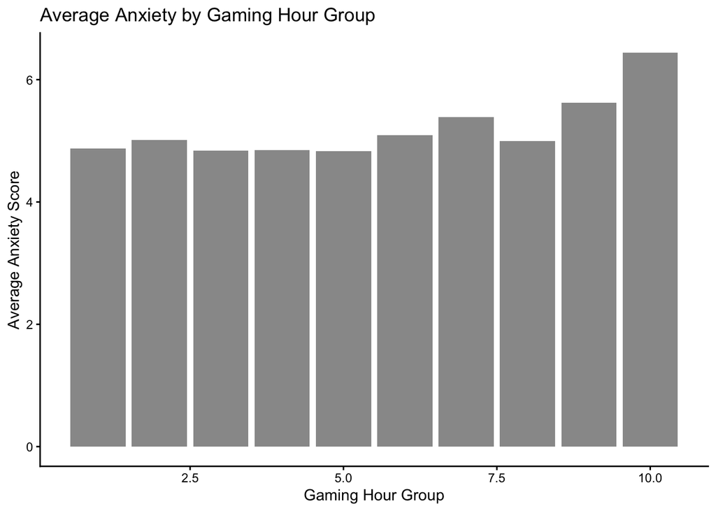

Although there is an upward trend, the increase is gradual rather than steep. This suggests that while gaming may have some association with anxiety, the effect size is relatively small, meaning it may not be practically significant in real-world settings.

Anxiety by Residence

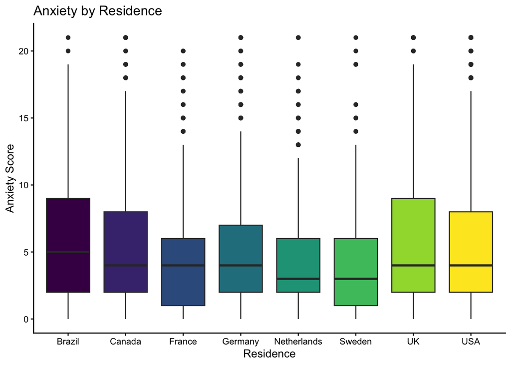

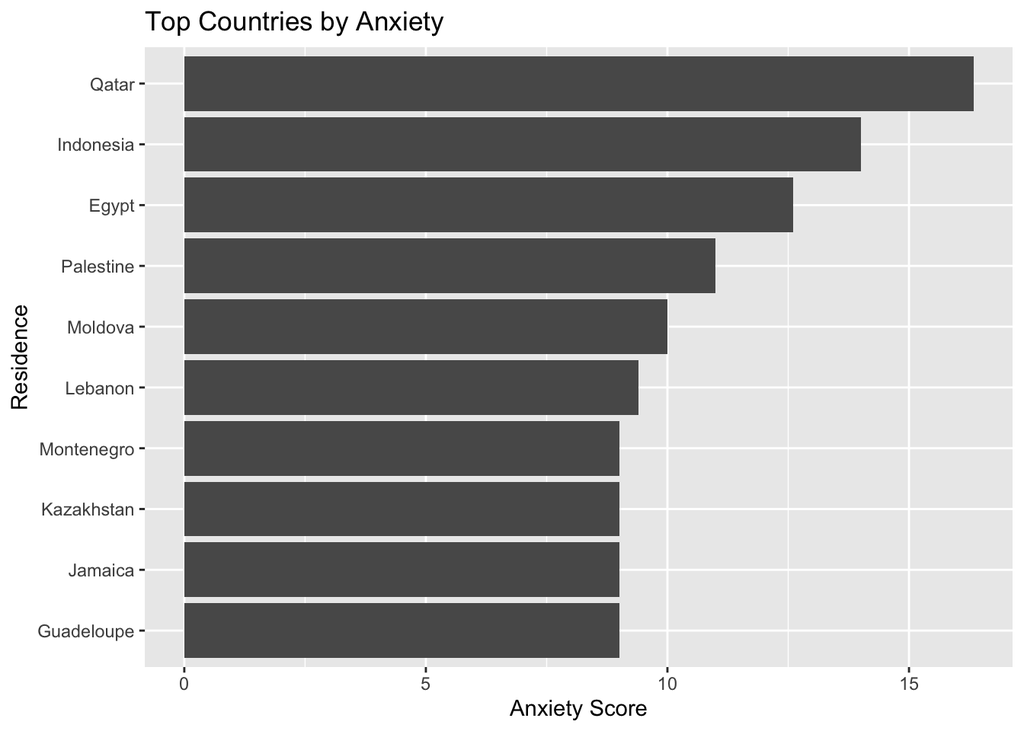

Why Do People Play Games?

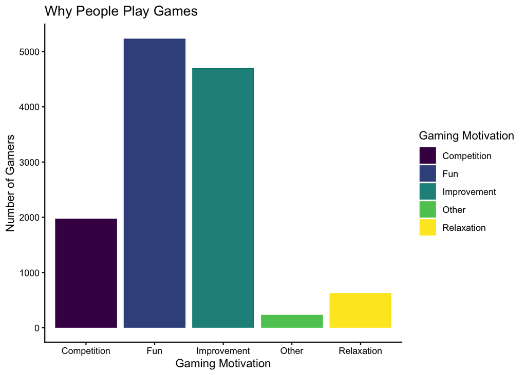

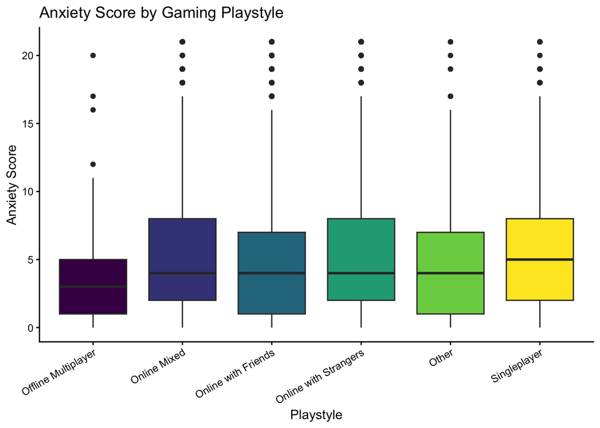

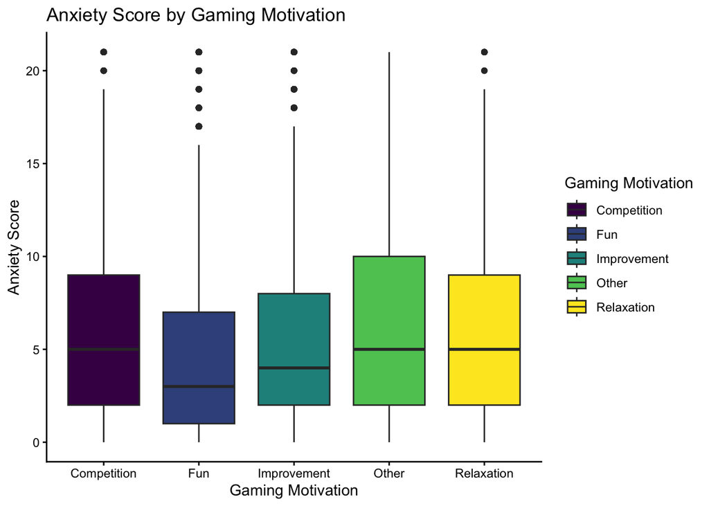

These graphs suggest that why people play and who they play with may influence anxiety more than gaming hours alone.

The playstyle results suggest that the social context of gaming plays a significant role in mental health outcomes. Players who engage in more social forms of gaming may experience different levels of anxiety compared to those who play alone. This indicates that gaming is not just an individual activity but also a social one, and its effects depend on the type of interaction involved.

Social Effects of Gaming

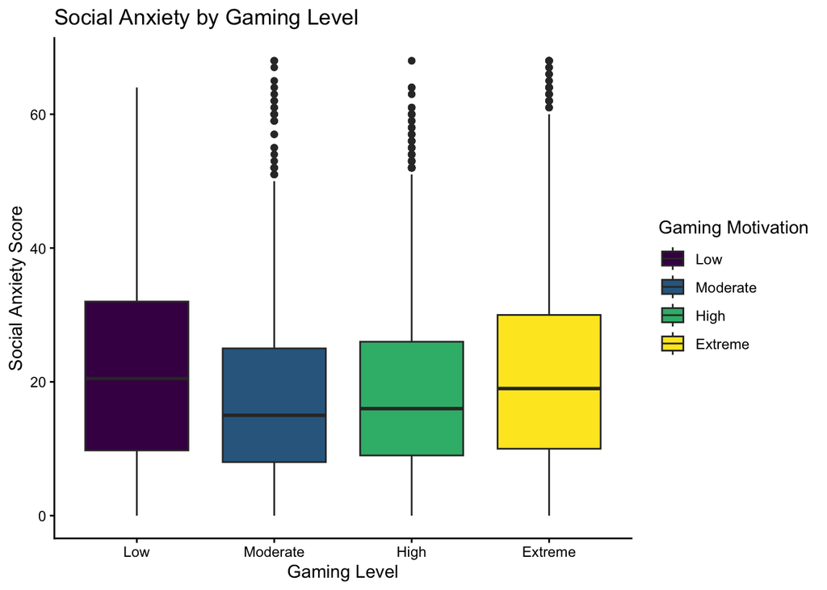

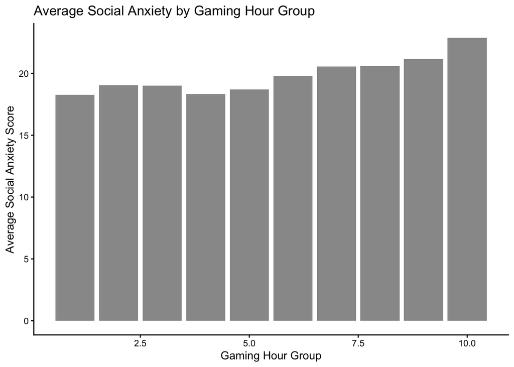

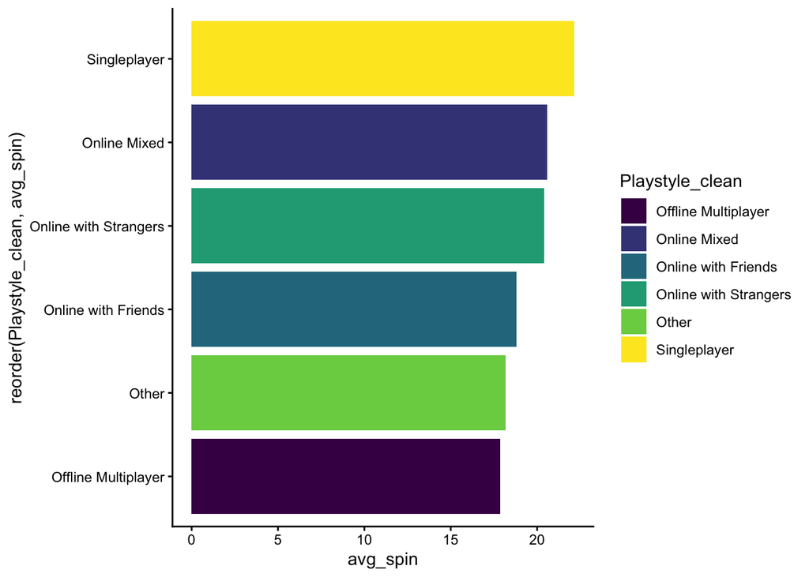

Social anxiety tends to increase with gaming intensity, but the effect is not strong. Playstyle provides more insight, suggesting that social interaction type plays a key role.

Although social anxiety appears to increase with gaming intensity, this does not necessarily mean gaming causes anxiety. It is equally possible that individuals with higher social anxiety are more likely to engage in gaming as a substitute for real-world interaction. This highlights a key limitation of the analysis: the inability to determine direction of causation. The relatively weak relationship between gaming intensity and social anxiety suggests that gaming is not a primary driver of social anxiety. Instead, it may act as an outlet for individuals who already experience social difficulties.

Life Satisfaction

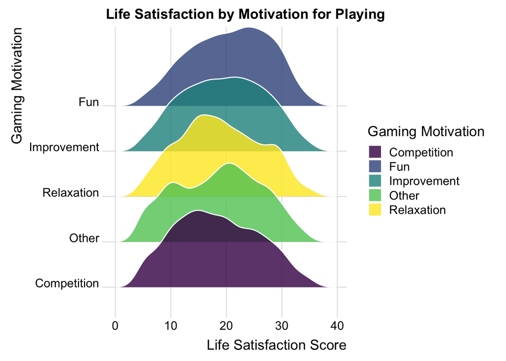

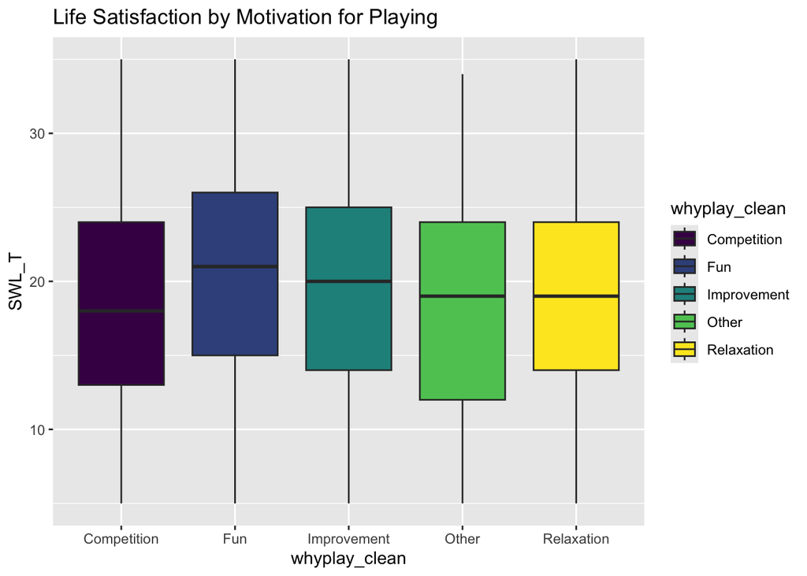

Demographic Trends

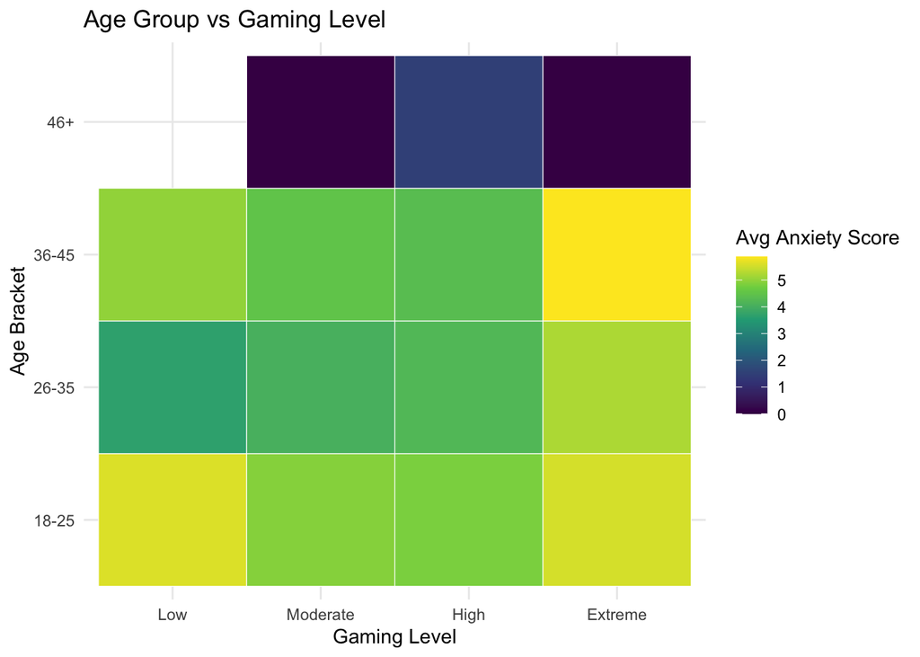

This shows that age interacts with gaming intensity, suggesting that life stage may influence how gaming affects well-being.

Different age groups may experience gaming differently due to life stage differences. Younger individuals may use gaming for socialization or identity formation, while older individuals may use it for stress relief or leisure. These differences may influence how gaming relates to anxiety and well-being across age groups.

## 5 5. Summary

This analysis explored how gaming behavior relates to mental well-being using survey data.

Key findings include:

Anxiety increases slightly with gaming intensity Social context (who you play with) is an important factor Motivation for gaming plays a significant role Life satisfaction is not strongly affected by gaming alone

Overall, this analysis shows that gaming does not have a simple or direct impact on well-being. Instead, its effects depend on multiple interacting factors, including motivation, social context, and individual differences. The findings suggest that gaming should not be viewed as inherently harmful or beneficial, but rather as an activity whose impact varies depending on how and why it is used.

Limitations include:

Self-reported data Correlation does not imply causation External factors such as environment and lifestyle are not fully captured

Future analysis could explore causal relationships or include additional variables such as productivity or long-term outcomes.